# Analyze of events on United States

Massimiliano Pinato

20 settembre 2016

# Data Processing

```r
library(dplyr) # I use that for manipulate data
library(data.table) #I use that for faster read csv file
library(lubridate) #I use that for manipulate date/time
```

```r
library(ggplot2) #I use that for plot
library(knitr) #I use that for knitr function like 'kable' for example
dfStorm <- fread("repdata-data-StormData.csv") #read file
```

```
##
Read 20.7% of 967216 rows
Read 43.4% of 967216 rows
Read 62.0% of 967216 rows
Read 78.6% of 967216 rows
Read 91.0% of 967216 rows
Read 902297 rows and 37 (of 37) columns from 0.523 GB file in 00:00:07
```

I use the “FATALITIES” variable to determine the event most dangerouse for human healt.

```r
dfStorm.overall <- dfStorm %>%
  group_by(EVTYPE) %>% #group by event type
  summarize(FAT = sum(FATALITIES)) #calculate total of fatalities for each event
summary(dfStorm.overall) #I want to view how are the events
```

```
##     EVTYPE               FAT
##  Length:985         Min.   :   0.00
##  Class :character   1st Qu.:   0.00
##  Mode  :character   Median :   0.00
##                     Mean   :  15.38
##                     3rd Qu.:   0.00
##                     Max.   :5633.00
```

I see that the 3rd quarter is still with zero value. It means that only a bit of events have fatalities. I try excluding events without fatalities.

```r
dfStorm.overall.zero <- dfStorm.overall %>%
  filter(FAT > 0)
summary(dfStorm.overall.zero) #I want to view how are the events
```

```
##     EVTYPE               FAT
##  Length:168         Min.   :   1.00
##  Class :character   1st Qu.:   1.00
##  Mode  :character   Median :   4.00
##                     Mean   :  90.15
##                     3rd Qu.:  19.75
##                     Max.   :5633.00
```

It seems better. Now about 40 events are over 19.75 fatalities. I still want to see how are those 40 events.

```r
dfStorm.overall.20 <- dfStorm.overall %>%
  filter(FAT > 19.75)
summary(dfStorm.overall.20) #I want to view how are the events
```

```
##     EVTYPE               FAT
##  Length:42          Min.   :  22.0
##  Class :character   1st Qu.:  39.0
##  Mode  :character   Median :  97.0
##                     Mean   : 348.7
##                     3rd Qu.: 205.5
##                     Max.   :5633.0
```

About 10 of these have more than 205. Now I want so know how much fatalities have those 205 respect al the others.

```r
dfStorm.overall.mt205 <- dfStorm.overall %>% #events with more than 205 fatalities
  filter(FAT > 205)
dfStorm.overall.lt205 <- dfStorm.overall %>% #events with less than 205 fatalities
  filter(FAT <= 205)
#calculate total and event numbers of 'more than 205 fatalities'
fat.mt205 <- sum(dfStorm.overall.mt205$FAT)
fat.mt205.cnt <- length(dfStorm.overall.mt205$EVTYPE)
#calculate total and event numbers of 'less than 205 fatalities'
fat.lt205 <- sum(dfStorm.overall.lt205$FAT)
fat.lt205.cnt <- length(dfStorm.overall.lt205$EVTYPE)
#prepare a dataframe in order to better present the data
df205 <- as.data.frame(
    rbind(
      c("More than 205 fatalities",fat.mt205,fat.mt205.cnt),
      c("Less than 205 fatalities",fat.lt205,fat.lt205.cnt)
    )
)
names(df205) <- c("GROUP","FATALITIES","EVTYPE.NUMBER")
```

Here the results. I see that the most of the fatalities (over 81%) is concentrate in a little part of events (only 11, about 1% of the overall events).

```r
library(knitr)
kable(df205)
```

| GROUP | FATALITIES | EVTYPE.NUMBER |
| --- | --- | --- |
| More than 205 fatalities | 12287 | 11 |
| Less than 205 fatalities | 2858 | 974 |

Now I can see a bar plot of those events.

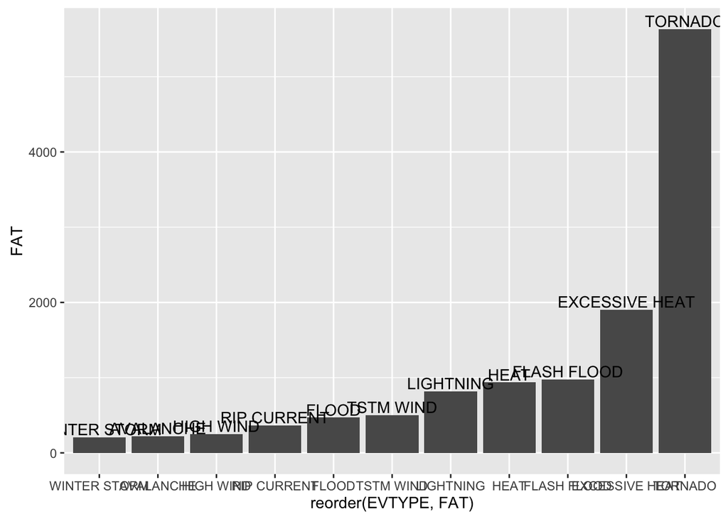

```r
g <- ggplot(dfStorm.overall.mt205,aes(x=reorder(EVTYPE,FAT),y=FAT))
g <- g + geom_bar(stat="identity",size=10)
g <- g + geom_text(aes(label=EVTYPE),vjust=-0.2)
g
```

# Results

I’ve extracted the most dangerous events. I’ve seen that 1% (about 10 events) of events produced the 81% of fatalities on overall events in the US.

```r
dfStorm.overall.mt205vsOthers <- dfStorm.overall.mt205 %>% arrange(desc(FAT))
dfStorm.overall.mt205vsOthers <- rbind(dfStorm.overall.mt205vsOthers,
            data.frame(EVTYPE =  "--- THE OTHERS ---" ,
                       FAT = sum(dfStorm.overall.lt205$FAT)))
kable(dfStorm.overall.mt205vsOthers)
```

| EVTYPE | FAT |
| --- | --- |
| TORNADO | 5633 |
| EXCESSIVE HEAT | 1903 |
| FLASH FLOOD | 978 |
| HEAT | 937 |
| LIGHTNING | 816 |
| TSTM WIND | 504 |
| FLOOD | 470 |
| RIP CURRENT | 368 |
| HIGH WIND | 248 |
| AVALANCHE | 224 |
| WINTER STORM | 206 |
| — THE OTHERS — | 2858 |

On thats events, Tornado is actually the most dangerous for the human health with more than 5000 fatalities.

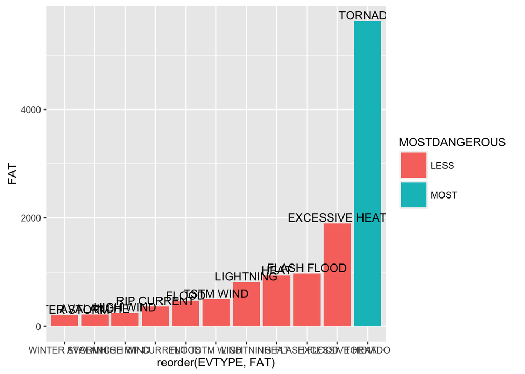

```r
dfStorm.overall.mt205 <- dfStorm.overall.mt205 %>%
  mutate(MOSTDANGEROUS = ifelse(EVTYPE == "TORNADO","MOST","LESS"))
g <- ggplot(dfStorm.overall.mt205,aes(x=reorder(EVTYPE,FAT),y=FAT,fill=MOSTDANGEROUS))
g <- g + geom_bar(stat="identity",size=10)
g <- g + geom_text(aes(label=EVTYPE),vjust=-0.2)
g
```